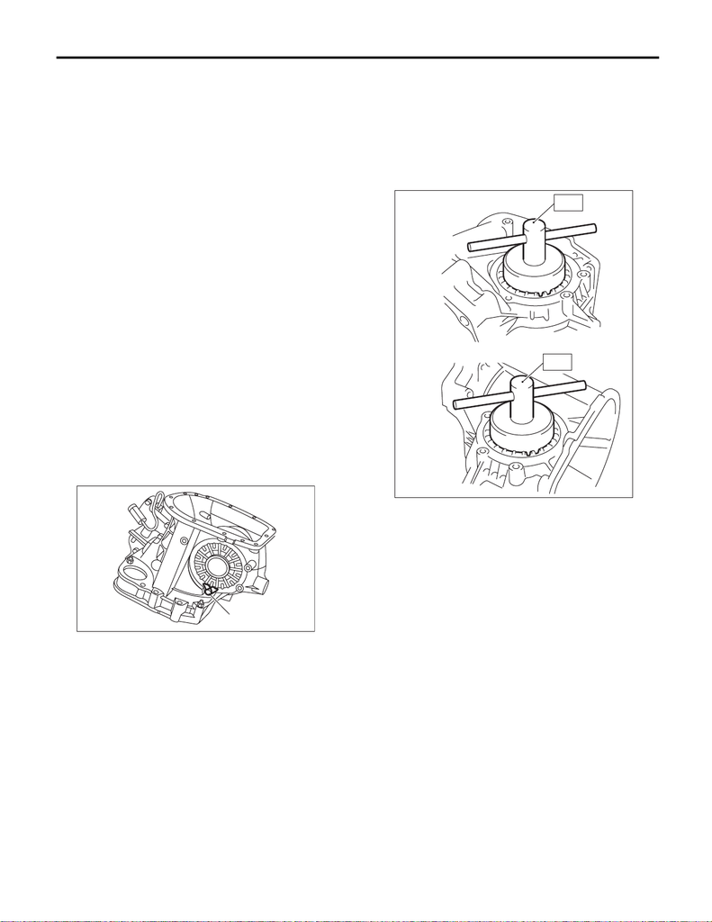

6MT(TY85)-99

Front Differential Assembly

MANUAL TRANSMISSION AND DIFFERENTIAL

23.Front Differential Assembly

A: REMOVAL

1) Remove the manual transmission assembly.

<Ref. to 6MT(TY85)-31, REMOVAL, Manual

Transmission Assembly.>

2) Prepare the transmission for overhaul. <Ref. to

6MT(TY85)-38, Preparation for Overhaul.>

3) Remove the neutral position switch, back-up

light switch and harness. <Ref. to 6MT(TY85)-41,

REMOVAL, Neutral Position Switch.> <Ref. to

6MT(TY85)-40, REMOVAL, Back-up Light

Switch.>

4) Remove the extension case. <Ref. to

6MT(TY85)-42, REMOVAL, Extension Case.>

5) Remove the transfer driven gear. <Ref. to

6MT(TY85)-54, REMOVAL, Transfer Driven

Gear.>

6) Remove the center differential. <Ref. to

6MT(TY85)-56, REMOVAL, Center Differential.>

7) Remove the transmission case. <Ref. to

6MT(TY85)-57, REMOVAL, Transmission Case.>

8) Remove the individual gear assemblies. <Ref. to

6MT(TY85)-63, REMOVAL, Main Shaft Assem-

bly.>

9) Remove the drive pinion shaft assembly. <Ref.

to 6MT(TY85)-92, REMOVAL, Drive Pinion Shaft

Assembly.>

10) Remove the retainer lock plates on both sides.

11) Remove the differential side retainers on both

sides using the ST.

ST1 18630AA010 WRENCH COMPL RETAIN-

ER (RH SIDE)

ST2 18630AA000 WRENCH ASSY (LH SIDE)

NOTE:

Be careful not to damage the section where the

clutch case retainer will be attached.

12) Remove the front differential.

(A) Retainer lock plate

MT-01022

(A)

(A) LH side

(B) RH side

(A)

(B)

MT-00657

ST1

ST2

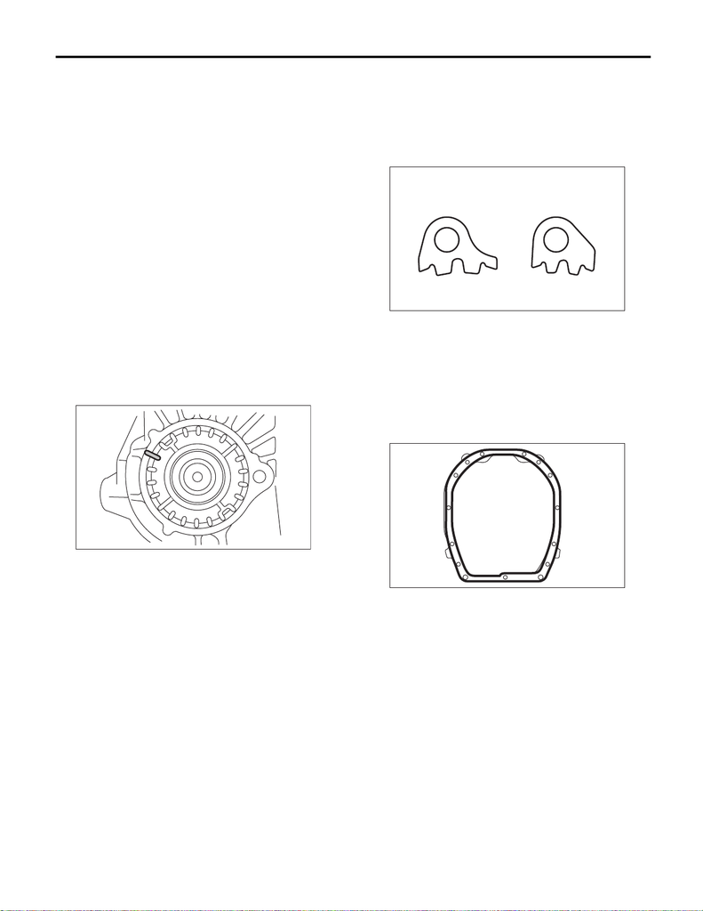

6MT(TY85)-100

Front Differential Assembly

MANUAL TRANSMISSION AND DIFFERENTIAL

B: INSTALLATION

1) Install the differential assembly to the clutch

housing.

2) Apply oil to the screw threads of the side retain-

er.

3) Remove the O-rings on both sides of the side re-

tainer.

4) Install the differential side retainers to both

sides, using the ST.

ST1 18630AA010 WRENCH COMPL RETAIN-

ER (RH SIDE)

ST2 18630AA000 WRENCH ASSY (LH SIDE)

NOTE:

Be careful not to damage the oil seal.

5) Inspect and adjust the hypoid gear backlash.

<Ref. to 6MT(TY85)-103, HYPOID GEAR BACK-

LASH, INSPECTION, Front Differential Assem-

bly.>

6) Inspect and adjust the tooth contact. <Ref. to

6MT(TY85)-97, ADJUSTMENT, Drive Pinion Shaft

Assembly.>

7) Mark the mating positions of the left and right

side retainers and the clutch housing.

8) Remove the differential side retainers from both

sides.

NOTE:

When removing the side retainer, record how many

times it was turned to remove.

9) Install new O-rings to the side retainers on both

sides.

10) Attach the differential side retainers to both

sides.

NOTE:

When attaching, turn the side retainer the same

number of turns it took to remove, and align the

marks.

11) Install the retainer lock plate.

Tightening torque:

25 N·m (2.5 kgf-m, 18.4 ft-lb)

NOTE:

Be careful not to confuse the left and right side re-

tainer lock plates.

12) Remove any remaining liquid gasket from the

clutch housing and adapter plate.

13) Apply liquid gasket to the clutch housing.

Liquid gasket:

THREE BOND 1215B or equivalent

14) Install the drive pinion shaft assembly. <Ref. to

6MT(TY85)-92, INSTALLATION, Drive Pinion

Shaft Assembly.>

15) Install the individual gear assemblies all at

once. <Ref. to 6MT(TY85)-64, INSTALLATION,

Main Shaft Assembly.>

16) Install the transmission case. <Ref. to

6MT(TY85)-59, INSTALLATION, Transmission

Case.>

17) Install the center differential. <Ref. to

6MT(TY85)-56, INSTALLATION, Center Differen-

tial.>

18) Install the transfer driven gear. <Ref. to

6MT(TY85)-54, INSTALLATION, Transfer Driven

Gear.>

19) Install the extension case. <Ref. to 6MT(TY85)-

42, INSTALLATION, Extension Case.>

MT-00658

(A) LH

(B) RH

MT-00659

(A) (B)

MT-00532

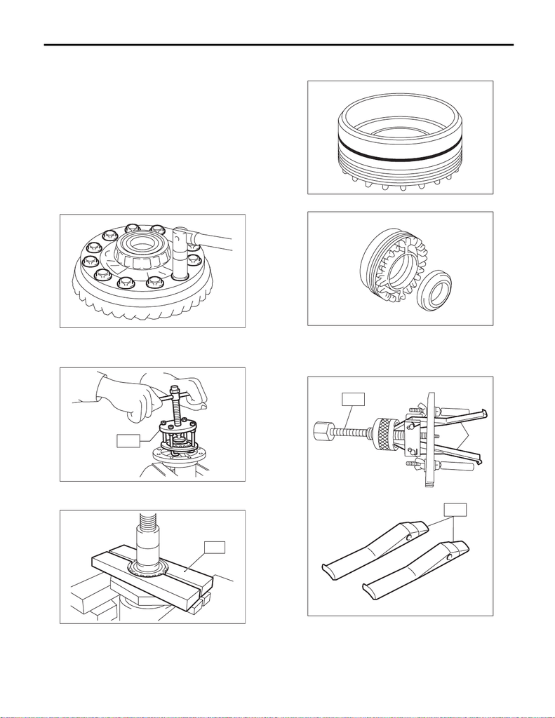

6MT(TY85)-101

Front Differential Assembly

MANUAL TRANSMISSION AND DIFFERENTIAL

20) Install the neutral position switch, back-up light

switch and harness. <Ref. to 6MT(TY85)-41, IN-

STALLATION, Neutral Position Switch.> <Ref. to

6MT(TY85)-40, INSTALLATION, Back-up Light

Switch.>

21) Install the manual transmission assembly to the

vehicle. <Ref. to 6MT(TY85)-33, INSTALLATION,

Manual Transmission Assembly.>

C: DISASSEMBLY

1. DIFFERENTIAL CASE

1) Fix the differential assembly on a vice, and re-

move the hypoid driven gear.

ST 18270KA020 SOCKET (E20)

2) Remove the side bearing of the hypoid driven

gear using the ST.

ST 399527700 PULLER SET

3) Using the ST, remove the taper roller bearing.

ST 498077000 REMOVER

2. SIDE RETAINER

1) Remove the O-rings.

2) Remove the oil seal.

3) Remove the claw of ST1, and attach the claw of

ST2.

ST1 398527700 PULLER ASSY

ST2 18760AA000 CLAW

MT-00660

MT-00663

ST

MT-00665

ST

(A) Claw

MT-03038

MT-03040

MT-00668

(A)

ST2

ST1

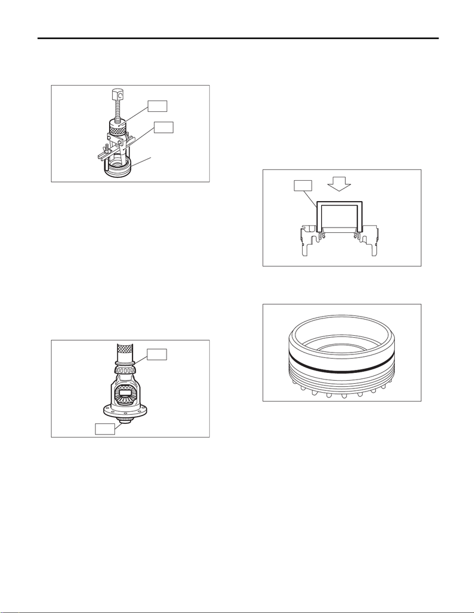

6MT(TY85)-102

Front Differential Assembly

MANUAL TRANSMISSION AND DIFFERENTIAL

4) Using the ST, remove the taper roller bearing

outer race from the side retainer.

ST1 398527700 PULLER ASSY

ST2 18760AA000 CLAW

D: ASSEMBLY

1. DIFFERENTIAL CASE

1) Using the ST, attach the RH and LH taper roller

bearing inner races to the differential case.

ST1 398437700 INSTALLER

ST2 398497701 SEAT

CAUTION:

Do not apply pressure in excess of 20 kN (2.0

ton, 2.2 US ton, 2.0 Imp ton).

NOTE:

Always replace the taper roller bearing inner race

and outer race as a set.

2) Install the hypoid driven gear to differential case.

ST 18270KA020 SOCKET (E20)

Tightening torque:

69 N·m (7.0 kgf-m, 50.9 ft-lb)

2. SIDE RETAINER

NOTE:

Install the oil seal and O-ring of side retainer after

the adjustment of backlash and tooth contact.

1) Attach the taper roller bearing outer race to the

side retainer.

2) Using the ST, install the oil seal.

ST 18675AA000 DIFFERENTIAL SIDE OIL

SEAL INSTALLER

NOTE:

• Use a new oil seal.

• Apply oil to the oil seal lips.

3) Install the O-rings.

NOTE:

Use new O-rings.

(A) Side retainer

MT-00669

(A)

ST2

ST1

MT-00670

ST1

ST2

AT-00226

ST

MT-03038

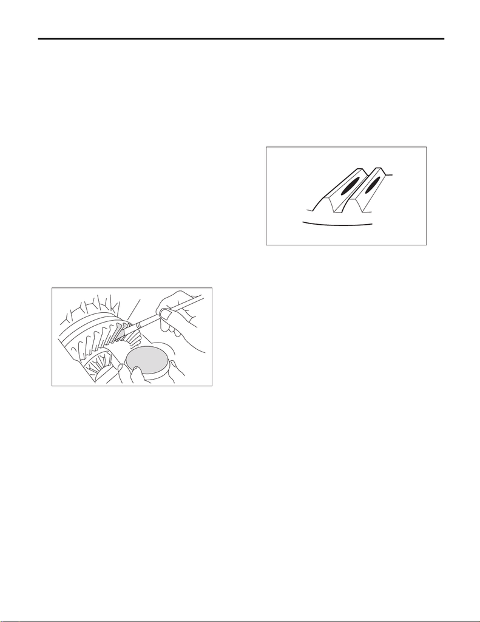

6MT(TY85)-103

Front Differential Assembly

MANUAL TRANSMISSION AND DIFFERENTIAL

E: INSPECTION

Repair or replace the differential in the following

cases:

• If gears are damaged, seized, or are excessively

worn.

• If differential case sliding surfaces are damaged,

seized, or are excessively worn.

• If there is damage, rust or wear in the bearings or

bearing locations.

• If the bearing does not rotate smoothly or an ab-

normal noise is emitted when turning.

1. HYPOID GEAR BACKLASH

Inspect the hypoid gear backlash. Adjust if out of

standard. <Ref. to 6MT(TY85)-103, HYPOID

GEAR BACKLASH, ADJUSTMENT, Front Differ-

ential Assembly.>

2. TOOTH CONTACT OF HYPOID GEAR

1) Check that the hypoid gear backlash is within the

standard value. Adjust if out of standard. <Ref. to

6MT(TY85)-103, HYPOID GEAR BACKLASH, AD-

JUSTMENT, Front Differential Assembly.>

2) Apply a thin uniform coat of lead-free red dye on

the surfaces of 3 or 4 hypoid driven gear teeth.

3) Attach the drive pinion shaft assembly, and affix

with at least 4 bolts.

NOTE:

Use old gaskets and washers to prevent the mating

surfaces of the housing from becoming damaged.

Tightening torque:

50 N·m (5.1 kgf-m, 36.9 ft-lb)

4) Turn the drive pinion shaft to the left and right for

several turns.

5) Remove the drive pinion shaft assembly, and in-

spect the mating condition of the teeth. If tooth con-

tact is not correct, perform adjustment. <Ref. to

6MT(TY85)-97, ADJUSTMENT, Drive Pinion Shaft

Assembly.>

• Correct tooth contact

NOTE:

In a no load condition, the tooth contact from the

center to the toe side is 50-60% (While driving, the

tooth contact will shift towards the heel side).

F: ADJUSTMENT

1. HYPOID GEAR BACKLASH

1) Attach the RH and LH side retainers.

ST1 18630AA010 WRENCH COMPL RETAIN-

ER (RH SIDE)

ST2 18630AA000 WRENCH ASSY (LH SIDE)

NOTE:

• Twist in the side retainer on the RH side a little

further than that of the LH side.

• WRENCH ASSY (499787000) can also be used.

2) Attach the drive pinion shaft assembly, and affix

with 5 bolts.

NOTE:

Use old gaskets and washers to prevent the mating

surfaces of the housing from becoming damaged.

Tightening torque:

50 N·m (5.1 kgf-m, 36.9 ft-lb)

3) Using the ST, loosen the differential side retainer

RH, and twist in the differential side retainer LH un-

til the hypoid driven gear just contacts the drive pin-

ion.

ST1 18630AA010 WRENCH COMPL RETAIN-

ER (RH SIDE)

ST2 18630AA000 WRENCH ASSY (LH SIDE)

MT-00652

(A) Toe side

(B) Heel side

(A)

(B)

MT-01401

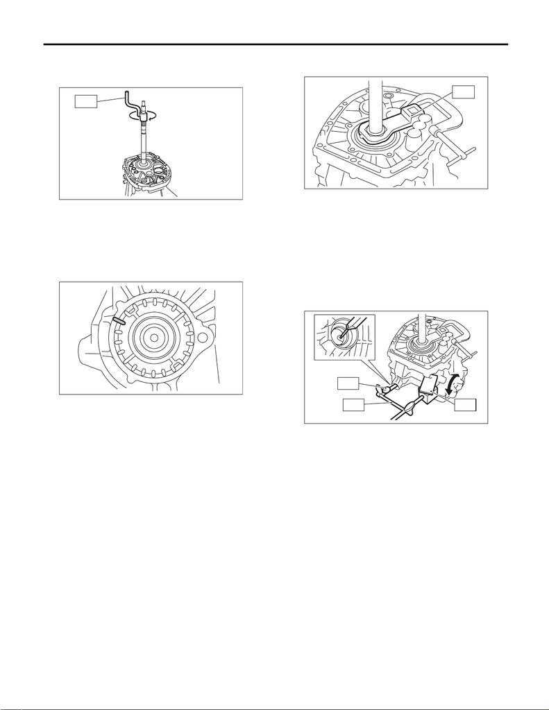

6MT(TY85)-104

Front Differential Assembly

MANUAL TRANSMISSION AND DIFFERENTIAL

4) Use the ST to turn the drive pinion shaft a few

times.

ST 18631AA000 HANDLE

5) Repeat steps 3) and 4) until differential side re-

tainer LH does not turn anymore. For differential

side retainer RH, screw in until the inner race and

outer race just comes into contact. This is the “ze-

ro” backlash state.

6) Mark the mating positions of the left and right

side retainers and the clutch housing.

7) Turn the back differential side retainer LH by 3

notches, and screw in the differential side retainer

RH by 3 notches.

8) Temporarily attach the LH side retainer lock

plate.

notches.

10) Temporarily attach the RH side retainer lock

plate.

NOTE:

• If the lock plate cannot be aligned, adjust the po-

sition toward the tightened side.

• The notch on the lock plate moves by 0.5 notch if

the lock plate is turned upside down when installed.

11) Use the ST to fix the drive pinion shaft in place.

ST 18621AA000 ADAPTER WRENCH

12) Install the SUBARU genuine axle shaft to the

front differential left and right sides.

Part No. 38415AA000 Axle shaft

13) Move the axle shaft, and measure the hypoid

gear backlash.

ST1 498255400 PLATE

ST2 498247001 MAGNET BASE

ST3 498247100 DIAL GAUGE

Hypoid gear backlash:

0.13 — 0.18 mm (0.0051 — 0.0071 in)

14) If the backlash is out of specified range, re-

move the left and right retainer lock plates and

loosen RH side differential side retainer. Then, ad-

just the LH side differential side retainer by turning

it, and attach the LH side retainer lock plate.

15) Screw in the RH side differential side retainer

until the inner race and outer race just come into

contact.

2. TOOTH CONTACT OF HYPOID GEAR

Regarding teeth contact conditions, refer to the

drive pinion section. <Ref. to 6MT(TY85)-103,

TOOTH CONTACT OF HYPOID GEAR, INSPEC-

TION, Front Differential Assembly.>

MT-00653

ST

MT-00658

ST

MT-00674

MT-00675

ST2

ST1

ST3